# Загрузка данных о расходах на рекламу из Яндекс Директ в Google Analytics

Алексей Селезнёв

2023-03-17

Начиная с версии `ryandexdirect 3.6.0` в пакет была добавлена функция `yadirGetCostData()`, которая позволяет вам получить данные о расходах для дальнейшей их загрузки в Google Analytics.

## Видео уроки

Вы можете посмотреть видео урок по данной теме, перейдя по [этой ссылке](https://youtu.be/T9y0Iuh5EWk).

## Создаём набор данных в Google Analytics

Изначально вам необходимо создать набор данных в Google Analytics.

1. Заходим в панель администратора
2. В области ресурс выбираем пункт “Импорт данных”

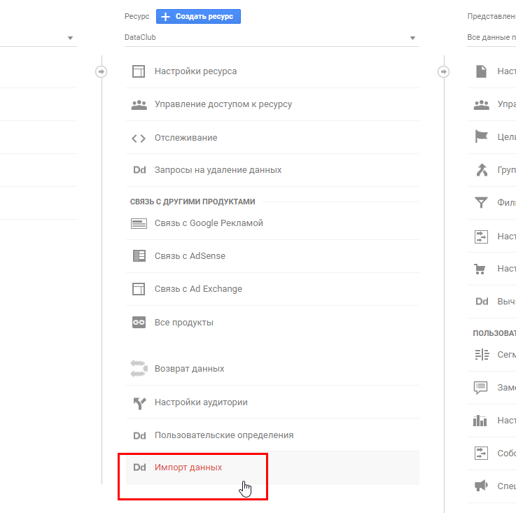

Панель администратора

3. Нажимае **Создать / Create**
4. Среды предложенных вариантов выбираем **Данные о расходах / Cost Data**

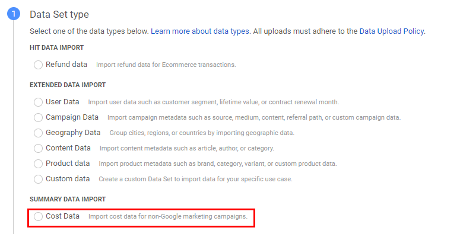

Выбираем тип набора данных

5. Задаём имя набора данных
6. Выбираем из выпадающего списка представления, в которые будут импортироваться данные о расодах

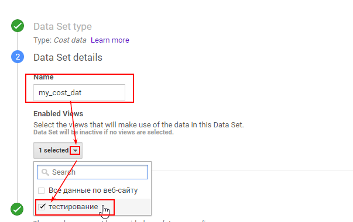

Выбираем представления

7. Настраиваем схему данных и выбираем перезаписывать данные если они соответвуют уже существующим строкам *Owerwrite*

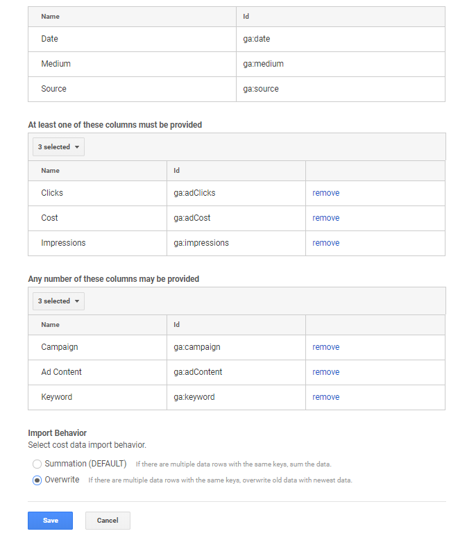

Настраиваем схему данных

8. Жмём сохранить.

Далее в интерфейсе появится созданный набор данных.

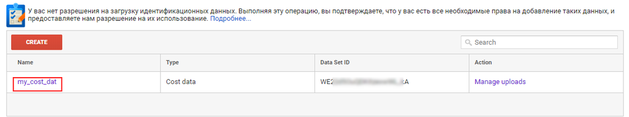

Созданный набор данных

В дальнейшем нам понадобится его идентификаторв.

Далее мы можем запросить данные о расходах из любого аккаунта к которому у нас есть доступ, и с помощью пакета `googleAnalyticsR` загрузить их в созданный источник данных.

```r
library(rfacebookstat)
library(googleAnalyticsR)

# fb options
options(ryandexdirect.username = 'your_yandex_username')

# auth
fbAuth()
ga_auth(email = "google_analytics@gmail.com")

# read data from facebook
cost_data <- yadirGetCostData(DateFrom        = '2020-03-01',
                              DateTo          = '2020-03-10',
                              Source          = 'yandex',
                              Medium          = 'cpc',
                              IncludeVAT      = "YES",
                              IncludeDiscount = "NO")

# upload into GA source
ga_custom_upload_file(accountId          = 2222222,
                      webPropertyId      = "UA-2222222-1",
                      customDataSourceId = 'M_XXXXX_Qudk-8g',
                      cost_data)
```

Если вы всё сделали правильно в разделе “Manage Uploads” вы увидите загруженные данные, и сообщение о статусе загрузке.

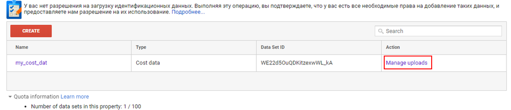

Раздел “Manage Uploads”

[figure not shown]

Статус загрузки

## Где искать данные о расходах на Яндекс Директ в Google Analytics

После загрузки в Google Analytics данные появляются не сразу, как правило должно пройти 1 - 1.5 часа. Найти данные о расходах можно в отчёте Анализ расходов:

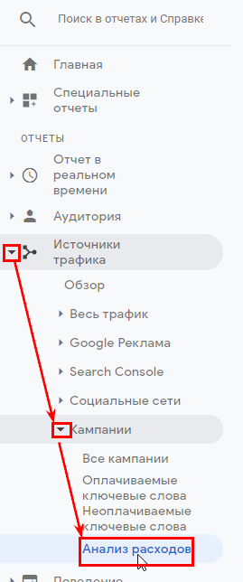

Данные о расходах в Google Analytics